# R Notebook

## Práctico 3

Usando *ggplot2*, Vamos a explorar un set de datos para indagar sobre cantidades, proporciones y distribuciones. Como lo venimos haciendo, te dejamos un dataset con el que podés trabajar el ejercicio, pero si querés usar uno de tu interés particular lo podés hacer.

En esta ocasión vamos a trabajar con una versión “recortada” de la EPH individual del primer trimestre de 2019. Esta está guaradada en la carpeta `data` con el nombre `eph_2019_limpia.rda`.

Primero, importá las liberías `ggplot` y `dplyr`. Luego importá la base.

```r
library(tidyverse)
load("data/eph_2019_limpia.rda")

df
```

| REGION | CH06 | ESTADO | CAT_OCUP | SEXO | PP08D1 | PONDIIO |
| --- | --- | --- | --- | --- | --- | --- |
| NEA | 28 | Inactivo | Inactivos | Mujeres | NA | 108 |
| NEA | 13 | Inactivo | Inactivos | Mujeres | NA | 108 |
| NEA | 1 | Menor de 10 años | Inactivos | Varones | NA | 108 |
| NEA | 41 | Ocupado | Empleado | Mujeres | 5000 | 108 |
| NEA | 9 | Menor de 10 años | Inactivos | Mujeres | NA | 108 |
| NEA | 51 | Ocupado | Cuenta propia | Varones | 0 | 141 |
| NEA | 63 | Inactivo | Inactivos | Varones | NA | 221 |
| NEA | 62 | Inactivo | Inactivos | Mujeres | NA | 221 |
| NEA | 24 | Inactivo | Inactivos | Mujeres | NA | 221 |
| NEA | 74 | Ocupado | Empleado | Varones | 3000 | 224 |

[output cut: 990 more lines]

## Ejercicio 1

¿Cómo se distribuyen los géneros entre los estados ocupacionales? Realizá un gráfico de barras, utilizá colores y funciones necesarias para formatear los datos logrando su correcta visualización.

Tené en cuenta que hay que filtrar aquellos casos que no corresponden (los menores de 10 años).

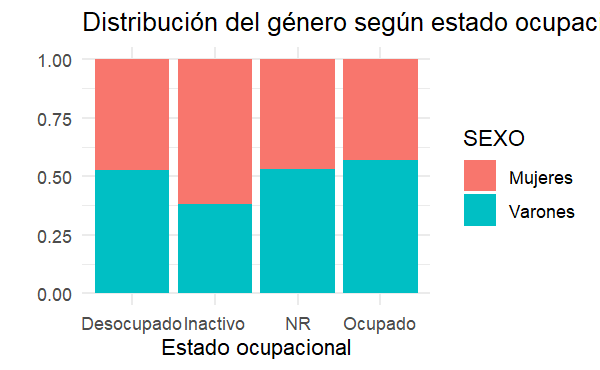

¿Qué participación tienen las mujeres y los varones para cada tipo de ocupación ?

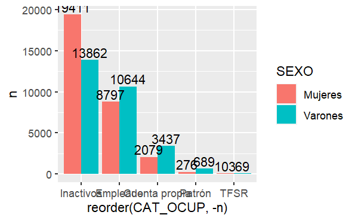

```r
df %>%
  group_by(CAT_OCUP, SEXO) %>%
  summarise(n=n()) %>%
  filter(CAT_OCUP != "Sin datos")%>%
  ggplot(aes(x = reorder(CAT_OCUP, -n), fill = SEXO, y = n))+
  geom_col(position = "dodge")+
  geom_text(aes(label = n), position = position_dodge(width=0.9),
            vjust = -0.25)
```

## Ejercicio 2

Mostrá en un gráfico la distribución de probabilidad de la variable ingresos de asalariados (PP08D1) según región.

De nuevo, tené en cuenta con filtrar aquellos casos que no corresponden (los no-asalariados).

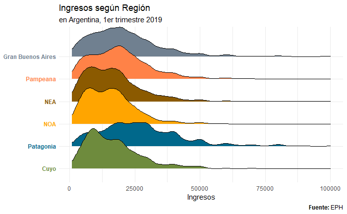

```r
df %>%
  filter(CAT_OCUP == "Empleado" & PP08D1 > 0) %>%
  mutate(color = case_when(
    REGION == "Patagonia" ~ "deepskyblue4",
    REGION == "Gran Buenos Aires" ~ "slategrey",
    REGION == "NOA" ~ "orange",
    REGION == "NEA" ~ "orange4",
    REGION == "Pampeana" ~ "sienna1",
    REGION == "Cuyo" ~ "darkolivegreen4"
  ), name = glue("<b style='color:{color}'>{REGION}")) %>%
  ggplot(aes(x = PP08D1, y = name, fill = color)) +
  geom_density_ridges() +
  scale_fill_identity()+
  scale_x_log10() +
  theme_minimal() +
  theme(legend.position = "none",
        plot.caption = element_markdown(lineheight = 1.2),
        axis.text.y = element_markdown(),
        axis.title.y = element_blank()) +
  labs(title = "Ingresos según Región",
       subtitle = "en Argentina, 1er trimestre 2019",
       x = "Ingresos",
       caption = "**Fuente:** EPH")+
  xlim(c(1000, 100000))
```

## Ejercicio 3

Escapando a las barras: utilizá un boxplot para describir la relación entre el nivel de ingresos de los asalariados por región y sexo.

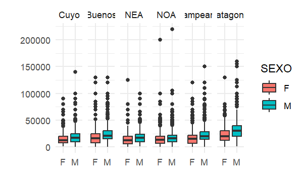

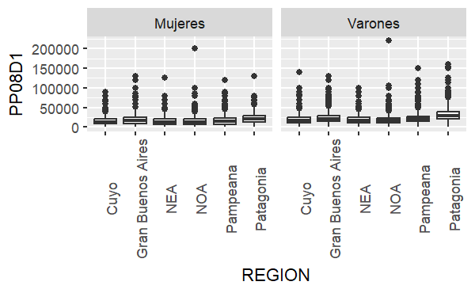